# NGS analysis report

Author: Aleksandra Gomółka

# Introduction

The analysis is based on the work by Rühl C and colleagues who performed the research on alternative splicing patterns in plants with increased and decreased levels of the 3 Arabidopsis Polypyrimidine-tract binding protein homologues in comparison to wild type samples, determined in duplicates.

The database includes, among others, two replicas of readings WT (wild type) and two replicas of readings: OE1, OE2, OE3 (over expressed). Further analysis focused on only OE1 and compared it to the wild type.

Source: https://www.ncbi.nlm.nih.gov/geo/query/acc.cgi?acc=GSE41433

# Alignment

### Subread analysis

The “subread” package available in R was used to carry out the alignment. Subread is a software tool package for the alignment of both DNA-seq and RNA-seq read data, quantification, and mutation detection. The Subread package consists of five separate tools:

- Subread, a read aligner for both RNA-seq and DNA-seq data,
- Subjunc, read aligner for RNA-seq data, detection of exon-exon junctions and gene fusion events,
- FeatureCounts, read counting,
- Sublong, for aligning long reads using the seed-and-vote technique
- ExactSNP, a single-nucleotide polymorphism discovery.

**Operation:** Sequence alignment  
**Input:** FASTA files  
**Output:** BAM files

Alignment is performed to align the analyzed sequences (input reads) against the reference sequence (genom) to determine where they are mapped and to finally quantify gene-level expression and discover differentially expressed genes.Aligner Subread carries out local alignments for RNA-seq reads in two steps.

**Step 1:** Building an index

The subread-buildindex (buildindex function in Rsubread) program builds an index for reference genome by creating a hash table in which keys are 16bp mers (subreads) extracted from the genome and values are their chromosomal locations.

```r
library(Rsubread)

#building index for RSubread (where TAIR9 is the genom)
buildindex(
  basename="TAIR9g",
  reference="data/TAIR9.fa")
```

**Step 2:** Aligning the reads (read mapping using Subjunc)

Subjunc not only performs read alignments but also detects exon-exon junctions. It is also used for others purposes of the RNA-seq data analysis such as alternative splicing analysis and genomic mutation detection. There are two files produced after mapping: one is a BAM-format file including mapping results and the other possible format is a BED-format file including discovered exon-exon junctions.

```r
#mapping WT_R1
subjunc("TAIR9g", "data/WT_R1.fastq", output_file = "WT_R1.bam",
        nthreads = 4, reportAllJunctions = TRUE)
```

```
Total_reads 10000000
Mapped_reads    8215965
Uniquely_mapped_reads   8031799
Multi_mapping_reads 184166
Unmapped_reads  1784035
Junctions   102673
Indels  27770
```

```r
#mapping WT_R2
subjunc("TAIR9g", "data/WT_R2.fastq", output_file = "WT_R2.bam",
        nthreads = 4, reportAllJunctions = TRUE)
```

```
Total_reads 10000000
Mapped_reads    8255368
Uniquely_mapped_reads   8074849
Multi_mapping_reads 180519
Unmapped_reads  1744632
Junctions   105005
Indels  35076
```

```r
#mapping OE1_R1
subjunc("TAIR9g", "data/OE_1_R1.fastq", output_file = "OE1_R1.bam",
        nthreads = 4, reportAllJunctions = TRUE)
```

```
Total_reads 5025600
Mapped_reads    4084273
Uniquely_mapped_reads   4009950
Multi_mapping_reads 74323
Unmapped_reads  941327
Junctions   94390
Indels  18767
```

```r
#mapping OE1_R2
subjunc("TAIR9g", "data/OE_1_R2.fastq", output_file = "OE1_R2.bam",
        nthreads = 4, reportAllJunctions = TRUE)
```

```
Total_reads 10000000
Mapped_reads    7723723
Uniquely_mapped_reads   7571944
Multi_mapping_reads 151779
Unmapped_reads  2276277
Junctions   106121
Indels  32901
```

As the output of this part of the analysis, we receive information about number of: total reads, mapped reads, uniquely mapped reads, multi mapping reads, unmapped reads, junctions and indels.

### Count reads by genomic features

The next step is to assign mapped sequencing reads to specified genomic features.

```r
fc <- featureCounts(c("WT_R1.bam","WT_R2.bam", "OE1_R1.bam", "OE1_R2.bam"),
                    annot.ext = "data/TAIR9.gtf",
                    isGTFAnnotationFile = TRUE,
                    juncCounts = TRUE,
                    nthreads = 4)
```

FeatureCounts is a general-purpose read summarization function that can assign mapped reads from genomic RNA sequencing to genomic features. The function takes as input a set of BAM files containing read mapping results, which was generated by subjunc. GTF was selected as the annotation format to specify the genomic. features. As a result of the function, information about the following components was obtained:

- **counts** - a data matrix containing read counts for each feature for each library
- **counts_junction (optional)** - a data frame including primary and secondary genes overlapping an exon junction
- **annotation** - a data frame with the annotation information for the features, like: GeneID, Chr (chromosome), Start, End and Length.
- **targets** - list of input files
- **stat** - statistics, a data frame giving number of successfully assigned reads (reads which have been mapped to the genome in region when features are: exons, genes) in each library and also number of unassigned reads falling in each filtering category (e.g. *unassigned and unmapped* reads which are not mapped anywhere, this may be due to contamination, fragments, remnants of the protocol or even incomplete genome sequence or *unassigned and no features* reads which may come from impurities or new genes/exons that have not yet been discovered)

```r
head(fc$counts)
```

```
##           WT_R1.bam WT_R2.bam OE1_R1.bam OE1_R2.bam
## AT1G01010       128        91         36         70
## AT1G01020       150       140         72        155
## AT1G01030        49        35         33         42
## AT1G01040       333       394        194        455
## AT1G01050       691       499        295        471
## AT1G01060      1085       728       1137        531
```

Particular attention was paid to the “counts” parameters. The columns contain the sample names and the rows contain the names of the genes. Note that the sequencing depth for OE1_R1 is significantly lower than the others. In order to make better comparisons, this number should be multiplied. The variance of the results is quite large. Determining the differences in the counts, as well as their significance, is the purpose of this statistical analysis.

# Visual examination

- In order to check the technical reproducibility, a graph was made where on the x-axis there are data from WT_R1 and on the y-axis from WT_R2.

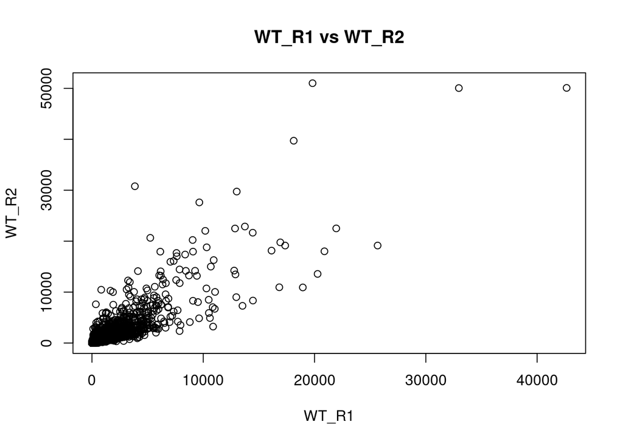

```r
plot(fc$counts[, "WT_R1.bam"], fc$counts[, "WT_R2.bam"],
     xlab = "WT_R1", ylab="WT_R2", main = "WT_R1 vs WT_R2")
```

The above graph is very difficult to analyze due to the accumulation of data in areas of low expression. We observe only a few points with higher expression. Nevertheless, such a result is expected that most of this stuff will show a low level of expression.

To capture more information, the following transformation of the function was performed.

*Logarithmic transformation*

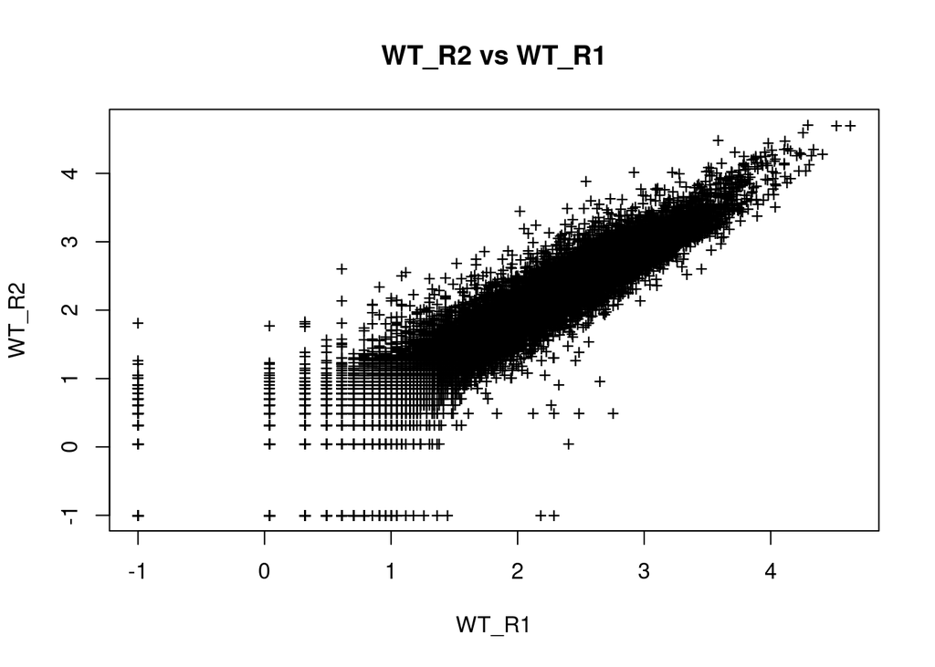

```r
plot(log10(fc$counts[, "WT_R1.bam"]+0.1), log10(fc$counts[, "WT_R2.bam"]+0.1),
     xlab = "WT_R1", ylab="WT_R2", main = "WT_R2 vs WT_R1", pch="+")
```

*Density plot* - to more accurately determine the amount of data in a given place

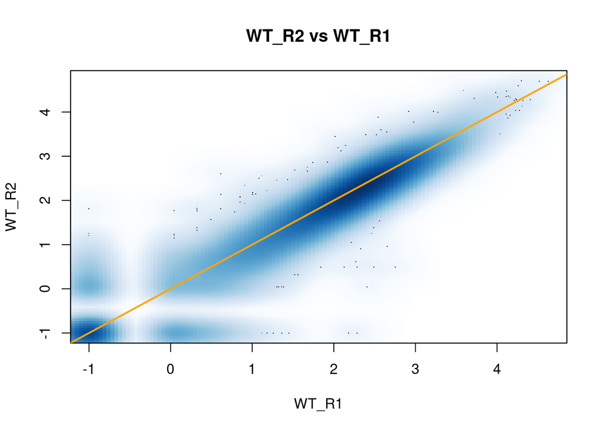

```r
smoothScatter(log10(fc$counts[, "WT_R1.bam"]+0.1), log10(fc$counts[, "WT_R2.bam"]+0.1),
              xlab = "WT_R1", ylab="WT_R2", main = "WT_R2 vs WT_R1")

abline(a=0, b=1, col="orange", lwd=2)
```

We distinguish places that are expressed in both WT_R1 and WT_R2, but also places where there is no expression in both cases. The data are arranged relatively symmetrically in relation to the diagonal, which proves the correctness of the reference data.

- In order to check the differences between the wild type and the one of the overexpressed, a graph of the relationship between OE1_R1 (y-axis) and WT_R1 (x-axis) was made.

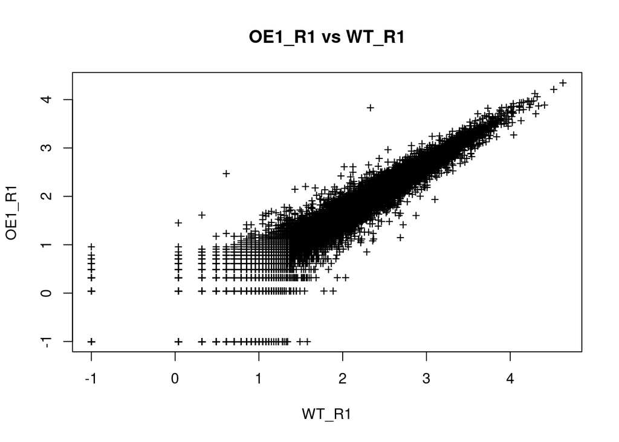

```r
plot(log10(fc$counts[, "WT_R1.bam"]+0.1), log10(fc$counts[, "OE1_R1.bam"]+0.1),
     xlab = "WT_R1", ylab="OE1_R1", main = "OE1_R1 vs WT_R1",pch="+")
```

We notice that the vast majority of the data is on the diagonal. However, we distinguish several points that are a bit further and deviate from the majority.

Below is the result of the pairs() function, which allows you to visualize all possible combinations of data. A matrix of scatterplot is produced as a function result.

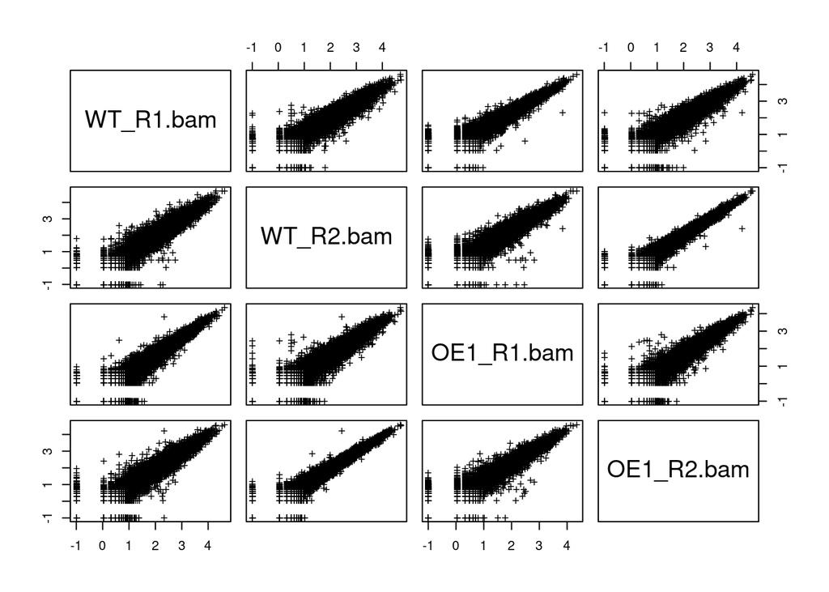

```r
pairs(log10(fc$counts+0.1), pch="+")
```

Note that the outliers genes is consistent regardless of what we compare it to (R1 or R2).

In the next step, we will focus on the gene AT3G01150 that is overexpressed and show where that gene is located on plot WT_R1 vs OE1_R1.

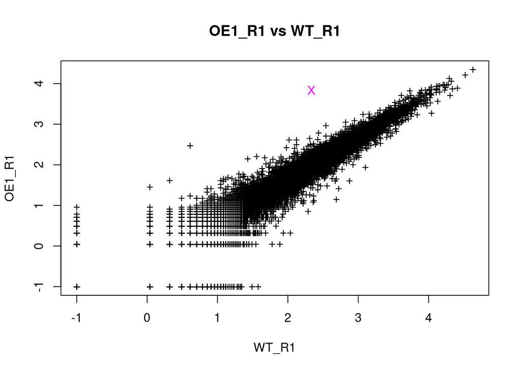

```r
gen.sel <- "AT3G01150"

pchs <- rep("+", dim(fc$counts)[1])
cols <- rep("black", dim(fc$counts)[1])
names(pchs) <- names(cols) <- rownames(fc$counts)

pchs[gen.sel] <- "X"
cols[gen.sel] <- "magenta"

plot(log10(fc$counts[, "WT_R1.bam"]+0.1), log10(fc$counts[, "OE1_R1.bam"]+0.1),
     xlab = "WT_R1", ylab="OE1_R1", main = "OE1_R1 vs WT_R1", pch=pchs, col=cols)
```

This visualization shows a selected overexpressed gene that deviates significantly from the rest of the dataset. We must take into account that these are only visual observations, which then need to be confirmed and evaluated by statistical tests.

Therefore, the next step will be to perform a differential expression analysis.

# Differential expression analysis (DEA)

### Limma

#### Limma for genes

In the limma approach to RNA-seq, read counts are converted to log2-counts-per-million (logCPM) and the mean-variance relationship is modeled either with precision weights or with an empirical Bayes prior trend. We distinguish two approaches: voom and limma-trend (the prior trend approach). The analysis used the precision weights approach called “voom”.

**Step 1:** Making a count matrix

RNA-seq data usually arrives in the form of FastQ or BAM files of unaligned reads. The reads need to be mapped to a reference genome or transcriptome, then summarized at the exon or gene level to produce a matrix of counts. Generally, it is created a matrix of read counts, with rows for genes and columns for samples.

```r
library(limma)

#count matrix
#changing the name of the columns and their order
genes.merged <- fc$counts[, c(3, 4, 1, 2)]
colnames(genes.merged) <- c("OE_1_R1", "OE_1_R2", "WT_R1", "WT_R2")

#extracting group info
#extraction of only the first two characters of the name and grouping into appropriate classes
samples <- substr(colnames(genes.merged), 0, 2)

#creating design data frame
design <- data.frame(OEs=ifelse(samples=="OE", 1,0),
                     WTs=ifelse(samples=="WT", 1, 0))
rownames(design) <- colnames(genes.merged)
design
```

```
##         OEs WTs
## OE_1_R1   1   0
## OE_1_R2   1   0
## WT_R1     0   1
## WT_R2     0   1
```

```r
#creating contrast(s) matrix
#contrasts it is useful with more groups
cm <- makeContrasts(OEvsWT=OEs-WTs,
                    levels=design)
cm
```

```
##       Contrasts
## Levels OEvsWT
##    OEs      1
##    WTs     -1
```

**Step 2:** Normalization and filtering

In this approach, the voom transformation is applied to the normalized and filtered DGEList object. DGEList object is created from a table of counts (rows=features, columns=samples), group indicator for each column, library size (optional) and a table of feature annotation (optional).

```r
dge <- DGEList(counts = genes.merged)
dge$samples
```

```
##         group lib.size norm.factors
## OE_1_R1     1  3897520            1
## OE_1_R2     1  7358555            1
## WT_R1       1  7822452            1
## WT_R2       1  7869433            1
```

In this case, we can observe summary statistics e.g. how many reads we have for every sample.

```r
#TMM normalization - normalization between groups with taking into account that most genes do not change their expression
dge <- calcNormFactors(dge)
dge$samples
```

```
##         group lib.size norm.factors
## OE_1_R1     1  3897520    1.0259230
## OE_1_R2     1  7358555    0.9740279
## WT_R1       1  7822452    1.0836568
## WT_R2       1  7869433    0.9234685
```

```r
summary(dge$counts)
```

```
##     OE_1_R1         OE_1_R2            WT_R1             WT_R2
##  Min.   :    0   Min.   :    0.0   Min.   :    0.0   Min.   :    0.0
##  1st Qu.:    7   1st Qu.:   13.0   1st Qu.:   17.0   1st Qu.:   13.0
##  Median :   51   Median :   92.0   Median :  113.0   Median :   93.0
##  Mean   :  163   Mean   :  307.8   Mean   :  327.2   Mean   :  329.2
##  3rd Qu.:  158   3rd Qu.:  291.0   3rd Qu.:  326.0   3rd Qu.:  299.0
##  Max.   :22198   Max.   :40528.0   Max.   :42653.0   Max.   :51016.0
```

We notice that the normalization factors have changed, but the “counts” didn’t change.

```r
# voom transformation - transformation to log2 scale
v <- voom(dge, design, plot=FALSE)
summary(v$E)
```

```
##     OE_1_R1           OE_1_R2            WT_R1            WT_R2
##  Min.   :-2.9995   Min.   :-3.8415   Min.   :-4.084   Min.   :-3.8614
##  1st Qu.: 0.9074   1st Qu.: 0.9134   1st Qu.: 1.046   1st Qu.: 0.8935
##  Median : 3.6870   Median : 3.6899   Median : 3.743   Median : 3.6855
##  Mean   : 2.9421   Mean   : 2.8903   Mean   : 2.871   Mean   : 2.9004
##  3rd Qu.: 5.3089   3rd Qu.: 5.3459   3rd Qu.: 5.267   3rd Qu.: 5.3650
##  Max.   :12.4387   Max.   :12.4652   Max.   :12.297   Max.   :12.7773
```

**Step 3:** Differential expression: voom

The next step is to perform variance estimation within groups and between groups. It is important in the next steps to be able to determine for each gene separately whether the differences between the groups are greater than the variance of all groups.

```r
#linear model fit with limma
#to refine the results we can use robust method to perform the fit with maximal number of iterations (9999) excluding outliers
f.t <- lmFit(v, design)

#contrasts fit
cf <- contrasts.fit(f.t, cm)

#Bayes correction - counteracts too many false positive results
fe <- eBayes(cf, proportion = 0.01)
```

When we analyze many features at the same time (and doing for them some statistical analysis), we must perform multiple testing correction to counteract a false positive results. In simple terms, the statistical significance level (p-value) should be reduced. To decrease the false discovery rate we use the Benjamini-Hochberg procedure. We assume that the features we are testing (genes in our case) are independent. Which is not entirely true, because there are many molecular mechanisms that affect gene regulation. Therefore, in future analyzes should try to use other methods (e.g BY) and compare the results.

```r
#multiple testing correction approach
adj.method = "BH"
```

```r
#top table showing treshold, p-value and applying multiple testing correction
limma.countsTMMvoom.genes <- topTable(fe, number=Inf, adjust.method=adj.method, sort.by='none')
head(limma.countsTMMvoom.genes)
```

```
##                logFC  AveExpr          t   P.Value adj.P.Val         B
## AT1G01010 -0.5384658 3.516210 -1.8126731 0.1165419 0.9999705 -4.485710
## AT1G01020  0.1130875 4.260716  0.4270953 0.6832468 0.9999705 -4.674720
## AT1G01030  0.3527949 2.617181  0.9635067 0.3701242 0.9999705 -4.601583
## AT1G01040  0.2664728 5.663624  0.9197004 0.3909330 0.9999705 -4.619157
## AT1G01050 -0.1000209 6.175049 -0.3954002 0.7053372 0.9999705 -4.686334
## AT1G01060  0.4224567 7.003161  0.6968894 0.5102757 0.9999705 -4.647452
```

We get statistics for each gene (gene names in rows), for example: local change (differences between groups (overexpressed vs wild type) on a log scale), avarage expression, T-statistic, p-value and addjusted p-value (after multiple testing correction). We usually set the p-value to 0.05. So we can determine for which genes or for how many genes the p-value is less than 5%.

```r
sum(limma.countsTMMvoom.genes$adj.P.Val<0.05)
```

```
## [1] 1
```

```r
which(limma.countsTMMvoom.genes$adj.P.Val<0.05)
```

```
## [1] 10029
```

```r
limma.countsTMMvoom.genes[which(limma.countsTMMvoom.genes$adj.P.Val<0.05),]
```

```
##            logFC AveExpr       t      P.Value  adj.P.Val         B
## AT3G01150 5.9992  7.9388 16.2625 1.831252e-06 0.04377607 -4.147026
```

Following the above steps, we can conclude that the only gene that shows a statistically significant change in expression is **AT3G01150**. From a statistical point of view, a p-value less than 0.05 means that the null hypothesis of no differences between the test type and the wild type should be rejected and the alternative hypothesis accepted.

However, the p-value for this gene is less than 5%, but not that much. This is due to the number of technical replicates, because the statistical analysis significantly depends on them. In our case we have only two technical replicates. For a more accurate analysis it would be better to use more technical replicates.

A similar analysis using a different multiple-testing correction, which takes into account the relationships between genes is shown below.

```r
adj.method = "BY"

limma.countsTMMvoom.genes <- topTable(fe, number=Inf, adjust.method=adj.method, sort.by='none')

sum(limma.countsTMMvoom.genes$adj.P.Val<0.05)
```

```
## [1] 0
```

```r
which(limma.countsTMMvoom.genes$adj.P.Val<0.05)
```

```
## integer(0)
```

```r
limma.countsTMMvoom.genes[which(limma.countsTMMvoom.genes$adj.P.Val<0.05),]
```

```
## [1] logFC     AveExpr   t         P.Value   adj.P.Val B
## <0 rows> (or 0-length row.names)
```

We get zero statistically significant results. Therefore, we can conclude that in the case of using only two technical replicates, this method is too rigorous.

The aim of the analysis was to investigate which genes differed significantly in the group.

**Step 4:** Visual examination

Below is a graphical visualization - plot with gen.sel marked including average expression (x-axis) and logFC (y-axis) to determine the dependence of variance on expression.

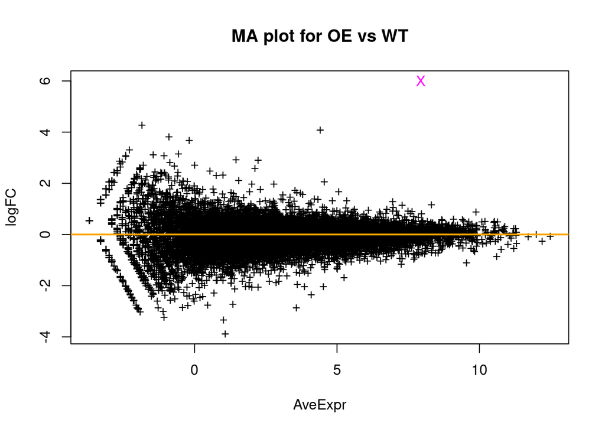

```r
gen.sel <- "AT3G01150"

pchs <- rep("+", dim(limma.countsTMMvoom.genes)[1])
cols <- rep("black", dim(limma.countsTMMvoom.genes)[1])
names(pchs) <- names(cols) <- rownames(limma.countsTMMvoom.genes)

pchs[gen.sel] <- "X"
cols[gen.sel] <- "magenta"

plot(limma.countsTMMvoom.genes$AveExpr, limma.countsTMMvoom.genes$logFC,
     xlab = "AveExpr", ylab="logFC", main = "MA plot for OE vs WT",pch=pchs, col=cols)
abline(h=0, col="orange", lwd=2)
```

We observe that the only one point (magenta point) is statistically significant. The vast majority of points (black points) are not statistically significant.

#### Limma for transcripts

The previously presented Subread analysis allowed to determine the level of gene expression. The next step will be to perform transcript-level analysis using other tools.

```r
load(file = "data/supplementary.RData")

head(trans.merged)
```

```
##                 OE_1_R1  OE_1_R2      WT_R1     WT_R2
## AT1G01010_ID1 83.673351 85.17584 142.173100 107.61582
## AT1G01020_ID8  8.750743 18.41270  21.360060  20.55019
## AT1G01020_ID9 37.910036 21.36570  22.675898  33.39722
## AT1G01020_ID4  9.650110 14.02244   8.363400  15.10687
## AT1G01020_ID5 11.817266 14.21590   8.250928  17.22066
## AT1G01020_ID6  8.541985 16.20686   9.877057   9.85386
```

Transcript data are presented in which the rows contain names corresponding to subsequent transcripts for given genes.

**Step 1:** Mapping between transcript name and gene name

```r
#mapping between transcriptID and geneID
trans.names <- row.names(trans.merged)

genes.names <- substr(trans.names, 1, 9) # it is required to specify the beginning and end of the gene name

mapping <- cbind(genes.names, trans.names) # bind by columns
rownames(mapping) <- trans.names
colnames(mapping) <- c("genes", "transcripts")

head(mapping)
```

```
##               genes       transcripts
## AT1G01010_ID1 "AT1G01010" "AT1G01010_ID1"
## AT1G01020_ID8 "AT1G01020" "AT1G01020_ID8"
## AT1G01020_ID9 "AT1G01020" "AT1G01020_ID9"
## AT1G01020_ID4 "AT1G01020" "AT1G01020_ID4"
## AT1G01020_ID5 "AT1G01020" "AT1G01020_ID5"
## AT1G01020_ID6 "AT1G01020" "AT1G01020_ID6"
```

As a result, we get a table in which we have information on how many transcripts we have, what are their names and what gene do they come from.

```r
trans.sel <- mapping[mapping[,"genes"] == gen.sel, "transcripts"]
trans.sel
```

```
##   AT3G01150_ID3   AT3G01150_ID4   AT3G01150_ID1   AT3G01150_ID2
## "AT3G01150_ID3" "AT3G01150_ID4" "AT3G01150_ID1" "AT3G01150_ID2"
```

There are four transcripts for our gene of interest.

- Repeating the analysis for “genes” (from the previous section) using a different approach

```r
samples <- substr(colnames(genes.merged), 0, 2)

design <- data.frame(OEs=ifelse(samples=="OE", 1,0),
                     WTs=ifelse(samples=="WT", 1, 0))
rownames(design) <- colnames(genes.merged)

#creating contrast(s) matrix
cm <- makeContrasts(OEvsWT=OEs-WTs, levels=design)

#TMM normalization
dge <- DGEList(counts = genes.merged)
dge <- calcNormFactors(dge)

# voom transformation
v <- voom(dge, design, plot=FALSE)

f.t <- lmFit(v, design) #linear model fit with limma
cf <- contrasts.fit(f.t, cm) #contrasts fit
fe <- eBayes(cf, proportion = 0.01) #Bayes correction

adj.method = "BH" #multiple testing correction approach

new.limma.countsTMMvoom.genes <- topTable(fe, number=Inf, adjust.method=adj.method,
                                          sort.by = 'none')

new.limma.countsTMMvoom.genes[which(new.limma.countsTMMvoom.genes$adj.P.Val<0.05),]
```

```
##              logFC  AveExpr        t      P.Value  adj.P.Val         B
## AT3G01150 6.123485 8.084137 16.10867 5.403837e-07 0.01291787 -4.100763
```

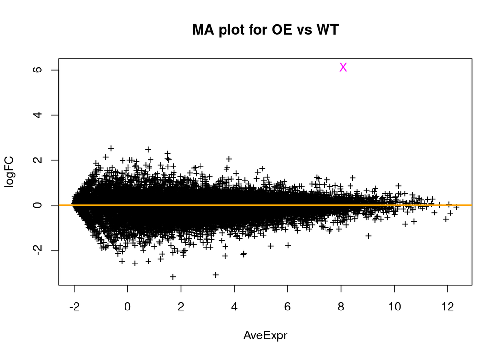

```r
gen.sel <- "AT3G01150"

pchs <- rep("+", dim(new.limma.countsTMMvoom.genes)[1])
cols <- rep("black", dim(new.limma.countsTMMvoom.genes)[1])
names(pchs) <- names(cols) <- rownames(new.limma.countsTMMvoom.genes)

pchs[gen.sel] <- "X"
cols[gen.sel] <- "magenta"

plot(new.limma.countsTMMvoom.genes$AveExpr, new.limma.countsTMMvoom.genes$logFC,
     xlab = "AveExpr", ylab="logFC", main = "MA plot for OE vs WT",pch=pchs, col=cols)
abline(h=0, col="orange", lwd=2)
```

The resulting graph is slightly different from the previous one. Both graphs are based on quantification of gene level but they use different approaches. The new approach generates less noise because data that show no statistically significant expression are close to zero (relatively evenly distributed along the marked line, contrary to the previous approach.

Let’s go back to transcript-based analysis.

**Step 2:** Making a count matrix

```r
#extractinng group info - this part is the same as the previous, so it is not necessary to run
trans_samples <- substr(colnames(trans.merged), 0, 2)

#creating design data frame
design <- data.frame(OEs=ifelse(trans_samples=="OE", 1, 0),
                     WTs=ifelse(trans_samples=="WT", 1, 0))

rownames(design) <- colnames(trans.merged)

#creating contrast(s) matrix
cm <- makeContrasts(OEvsWT = OEs-WTs, levels = design)
```

**Step 3:** Normalization and filtering: voom

```r
#TMM normalization
dge <- DGEList(counts = trans.merged)
dge$samples
```

```
##         group lib.size norm.factors
## OE_1_R1     1  7908292            1
## OE_1_R2     1  7536655            1
## WT_R1       1  7797561            1
## WT_R2       1  7970894            1
```

```r
dge <- calcNormFactors(dge)
dge$samples
```

```
##         group lib.size norm.factors
## OE_1_R1     1  7908292    0.9861773
## OE_1_R2     1  7536655    1.0302895
## WT_R1       1  7797561    1.0238564
## WT_R2       1  7970894    0.9612729
```

```r
#voom transformation
v <- voom(dge, design, plot=FALSE)
```

**Step 4:** Differential expression

```r
#linear model fit with limma
f.t <- lmFit(v, design)

#contrast fit
cf <- contrasts.fit(f.t, cm)

#Bayes correction
fe <- eBayes(cf, proportion =0.01)
```

```r
#multiple testing correction approach
adj.method = 'BH'
```

```r
limma.countsTMMvoom.trans <- topTable(fe, number = Inf, adjust.method = adj.method,
                                          sort.by = 'none')
```

```r
limma.countsTMMvoom.trans[which(limma.countsTMMvoom.trans$adj.P.Val < 0.05),]
```

```
##                  logFC  AveExpr        t      P.Value   adj.P.Val        B
## AT3G01150_ID4 6.906772 7.675772 17.69561 3.988909e-08 0.002289953 -4.20909
```

We see that only one transcript (**ID4**) for the **AT3G01150** gene shows statistically significant expression. We also see a change in the logFC parameter, which is now close to 7, compared to the previous value of 6. Transcript number 4 appears to be responsible for the level of expression of the gene, while the others have little influence.

**Step 5:** Visual examination

Then, a graph was made showing all four transcripts for gen of interest.

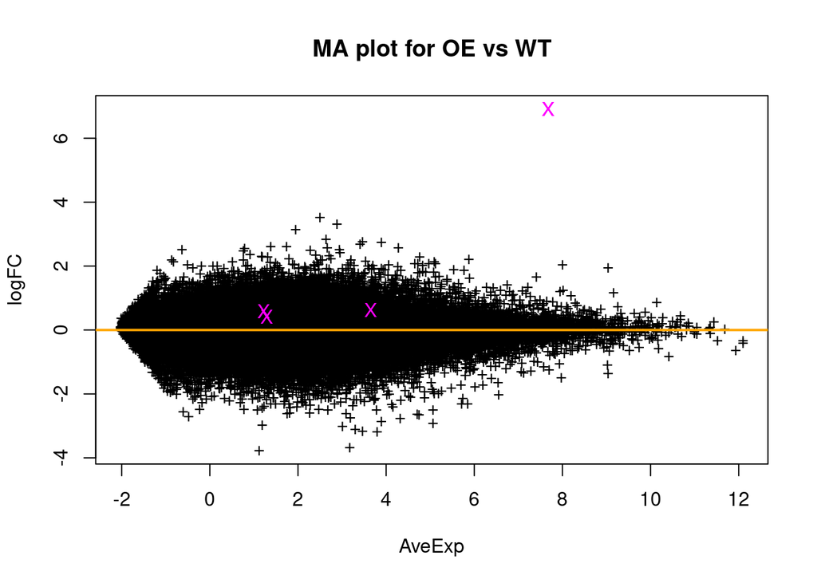

```r
# Ma-plot with the trans.sel marked
pchs <- rep("+", dim(limma.countsTMMvoom.trans)[1])
cols <- rep("black", dim(limma.countsTMMvoom.trans)[1])
names(pchs) <- names(cols) <- rownames(limma.countsTMMvoom.trans)

pchs[trans.sel] <- "X"
cols[trans.sel] <- "magenta"

plot(limma.countsTMMvoom.trans$AveExpr, limma.countsTMMvoom.trans$logFC,
     xlab="AveExp", ylab="logFC", main="MA plot for OE vs WT", pch=pchs, col=cols)
abline(h=0, col ="orange", lwd =2)

points(limma.countsTMMvoom.trans[trans.sel,]$AveExpr,
       limma.countsTMMvoom.trans[trans.sel,]$logFC,
       xlab="AveExp",
       ylab="logFC",
       main="Transcript - MA plot for OE vs WT",
       pch=pchs[trans.sel], col=cols[trans.sel])
```

The three remaining transcripts, which do not have a significant effect on the level of gene expression, are located within the black dots, which confirms their statistically insignificant effect. The previously mentioned transcript with a statistically significant expression stands out from the others and is located far from the zero line.

```r
limma.countsTMMvoom.trans[trans.sel,]
```

```
##                   logFC  AveExpr          t      P.Value   adj.P.Val         B
## AT3G01150_ID3 0.4142790 1.284738  0.6202899 5.509593e-01 0.999996518 -4.609800
## AT3G01150_ID4 6.9067717 7.675772 17.6956123 3.988909e-08 0.002289953 -4.209090
## AT3G01150_ID1 0.5932008 1.221358  0.9732981 3.566752e-01 0.999996518 -4.596818
## AT3G01150_ID2 0.6315154 3.647756  1.2894979 2.304340e-01 0.999996518 -4.579757
```

The graphical visualization is also confirmed by the calculated data. The logFC parameter for ID4 is close to 7, compared to the others, which reach values in the range of 0.4-0.6. Even if there is no general objective justification for particular log-fold change threshold, we can confidently say that the ID4 transcript is overexpressed compared to the rest.

The obtained results may indicate the procedure used, which e.g. may not have taken into account all alternative transcripts. This claim is also supported by the quite high wild-type expression of this transcript.

- Making a scatter plot with gene expression on x-axis and transcript expression on y-axis with our gene/transcript of interest marked with different color and sign:
  - WT_R1
  - OE_1_R1

The plots will allow us to determine the expression of each transcript for all genes (with their expression).

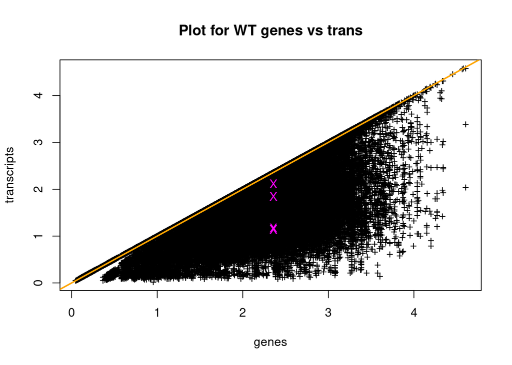

```r
#WT_R1
plot(log10(genes.merged[mapping[,"genes"],3] +0.1),
     log10(trans.merged[,3]+0.1), xlab="genes", ylab="transcripts",
     main="Plot for WT genes vs trans", pch=pchs, col=cols)

abline(a=0, b=1, col="orange", lwd=2)

points(log10(genes.merged[mapping[trans.sel,"genes"],3]+0.1),
       log10(trans.merged[trans.sel,3]+0.1), pch=pchs[trans.sel], col=cols[trans.sel])
```

For the wild type we see that there is one point that is highly expressed while the others have lower expression. Actually, the mRNA transcript is sequenced and the expression of the gene is the sum of expression of all the transcripts of this gene. Consequently, there are no points above the diagonal, because it is not possible for the transcript expression level to be greater than the gene expression level (considering the log10 scale in the graph). Diagonal (the orange line) thus represents a situation where transcript expression is equal to gen expression (there is only one transcript per gene or there are many transcripts but only the one takes up the whole expression).

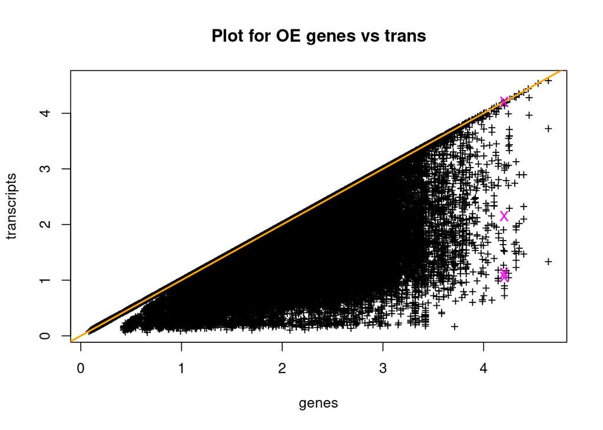

```r
#OE_1_R1
plot(log10(genes.merged[mapping[,"genes"],1] +0.1),
     log10(trans.merged[,1]+0.1), xlab="genes", ylab="transcripts",
     main="Plot for OE genes vs trans", pch=pchs, col=cols)

abline(a=0, b=1, col="orange", lwd=2)

points(log10(genes.merged[mapping[trans.sel,"genes"],1]+0.1),
       log10(trans.merged[trans.sel,1]+0.1), pch=pchs[trans.sel], col=cols[trans.sel])
```

For the over expressing type, we observe a dominant influence of only one transcript, which is on the diagonal. Which means it takes up almost all of the gene expression. We also observe the occurrence of one transcript, which is located between the higher and lower expressed ones.

```r
limma.countsTMMvoom.trans[trans.sel, ]
```

```
##                   logFC  AveExpr          t      P.Value   adj.P.Val         B
## AT3G01150_ID3 0.4142790 1.284738  0.6202899 5.509593e-01 0.999996518 -4.609800
## AT3G01150_ID4 6.9067717 7.675772 17.6956123 3.988909e-08 0.002289953 -4.209090
## AT3G01150_ID1 0.5932008 1.221358  0.9732981 3.566752e-01 0.999996518 -4.596818
## AT3G01150_ID2 0.6315154 3.647756  1.2894979 2.304340e-01 0.999996518 -4.579757
```

Statistical analysis confirmed an increase in the expression level of the ID4 transcript. Addjustment p-value reaches less than 0.05 (5%) - value lower than the assumed significance level.

### EdgeR

Then, analysis was performed using another tool - EdgeR.

EdgeR offers many variants on analyses. The glm (linear model) approach is more popular than the classic approach as it offers great flexibilities. There are two testing methods:

- likelihood ratio tests
- quasi-likelihood F-tests

The quasi-likelihood method is highly recommended for differential expression analyses of bulk RNA-seq data as it gives stricter error rate control by accounting for the uncertainty in dispersion estimation. The likelihood ratio test can be useful in some special cases such as single cell RNA-seq and datasets with no replicates.

In the analysis of RNA-seq, the quasi-likelihood F-test approach is most often used, but in our case we have only two technical replicates and four samples, which may affect the results. Therefore, both methods were used and the obtained results were compared.

#### EdgeR for genes

```r
library(edgeR)

group <- factor(c(2,2,1,1)) #overexpression type (group nr 2), wild type (group nr 1)
y <- DGEList(counts=genes.merged, group=group) #merge object to a table of counts

keep <- filterByExpr(y)
y <- y[keep,,keep.lib.sizes=FALSE]
y <- calcNormFactors(y) #calculating of normalization factors (TMM)
design <- model.matrix(~group) #creating design data frame - determination of groups for each sample
y <- estimateDisp(y, design) #calculation of variance within all groups and between groups
```

- **To perform quasi-likelihood F-tests:**

```r
fit <- glmQLFit(y,design) #linear model
qlf <- glmQLFTest(fit,coef=2) #F-test application
topTags(qlf)
```

```
## Coefficient:  group2
##               logFC    logCPM         F       PValue       FDR
## AT3G01150  6.138960 10.190710 123.18195 1.855862e-05 0.3589051
## AT3G12500 -2.176598  4.737275  48.13124 3.153375e-04 0.9999928
## AT5G35935 -3.075276  2.490229  32.24676 9.818753e-04 0.9999928
## AT1G48750 -2.230349  2.531099  31.26269 1.069428e-03 0.9999928
## AT4G21400  2.026162  4.183189  25.52193 1.851809e-03 0.9999928
## AT1G43800 -3.438567  4.335415  23.53449 2.294007e-03 0.9999928
## AT1G64780 -1.799691  3.979097  23.03761 2.425733e-03 0.9999928
## AT5G10140  2.328059  2.016935  20.52569 3.268141e-03 0.9999928
## AT2G29330 -1.652511  3.108662  20.20560 3.401674e-03 0.9999928
## AT4G25090 -1.784765  2.784923  19.05751 3.943800e-03 0.9999928
```

```r
#including all "tags" (genes)
genes.QLF.tt <- topTags(qlf, n=Inf)
sum(genes.QLF.tt$table$FDR < 0.05)
```

```
## [1] 0
```

- **To perform likelihood ratio tests:**

```r
fit <- glmFit(y,design)
lrt <- glmLRT(fit,coef=2)
genes.LR.tt <- topTags(lrt)
genes.LR.tt
```

```
## Coefficient:  group2
##               logFC    logCPM        LR       PValue          FDR
## AT3G01150  6.139049 10.190710 120.02788 6.237774e-28 1.206323e-23
## AT3G12500 -2.176526  4.737275  27.98976 1.219590e-07 1.175336e-03
## AT5G35935 -3.075749  2.490229  27.21197 1.823263e-07 1.175336e-03
## AT1G43800 -3.437107  4.335415  21.69911 3.189387e-06 1.541989e-02
## AT1G48750 -2.229820  2.531099  20.41841 6.222832e-06 2.406867e-02
## AT4G21400  2.026104  4.183189  18.49208 1.706121e-05 5.499112e-02
## AT5G10140  2.328703  2.016935  16.03440 6.220190e-05 1.558983e-01
## AT1G64780 -1.799883  3.979097  15.96599 6.449074e-05 1.558983e-01
## AT3G43190 -2.453638  4.256838  15.54313 8.064428e-05 1.732866e-01
## AT1G12805 -2.667034  1.478025  13.90822 1.919575e-04 3.712266e-01
```

```r
sum(genes.LR.tt$table$FDR < 0.05)
```

```
## [1] 5
```

The most significant is our gene of interest (AT3G01150) but we have also four genes with significant difference.

Each of these approaches fails to expectations. A deeper analysis would be needed to confirm whether the genes that show a significant difference are somehow related to each other and to the main over expressed gene (AT3G01150). Over expression of one gene may affect the level of other genes.

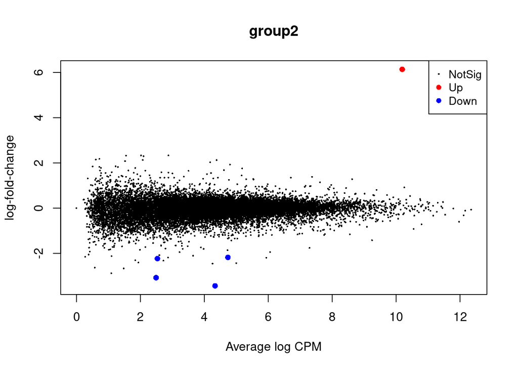

```r
plotMD(lrt)
```

The summary chart for likelihood ratio tests method confirmed the previously performed statistical analyses.

#### EdgeR for transcripts

```r
group <- factor(c(2,2,1,1)) #overexpression type (group nr 2), wild type (group nr 1)
y <- DGEList(counts=trans.merged,group=group) #merge object to a table of counts

keep <- filterByExpr(y)
y <- y[keep,,keep.lib.sizes=FALSE]
y <- calcNormFactors(y) #calculating of normalization factors (TMM)
design <- model.matrix(~group) #creating design data frame - determination of groups for each
y <- estimateDisp(y, design) #calculation of variance within all groups and between groups
```

- **To perform quasi-likelihood F-tests:**

```r
fit <- glmQLFit(y,design) #linear model
qlf <- glmQLFTest(fit,coef=2) #F-test application
trans.QLF.tt <- topTags(qlf, n=Inf)
head(trans.QLF.tt)
```

```
## Coefficient:  group2
##                    logFC    logCPM         F       PValue        FDR
## AT3G01150_ID4   6.914123 10.167386 145.37079 1.822853e-06 0.07844828
## AT4G14880_ID19 -2.862279  5.725390  40.53065 2.034760e-04 0.99999162
## AT4G01800_ID1  -2.666800  5.322185  37.97061 2.545164e-04 0.99999162
## AT5G35935_ID1  -3.796600  2.192294  32.14259 4.460392e-04 0.99999162
## AT3G52220_ID3   2.695176  4.000616  31.43121 4.803630e-04 0.99999162
## AT3G10970_ID10 -2.765422  3.803689  31.14268 4.952203e-04 0.99999162
```

```r
sum(trans.QLF.tt$table$FDR < 0.05)
```

```
## [1] 0
```

Again, we observe that the previously selected AT3G01150_ID4 shows the highest log-fold change but this change is not statistically significant (FDR > 0.05).

- **To perform likelihood ratio tests:**

```r
fit <- glmFit(y,design)
lrt <- glmLRT(fit,coef=2)
trans.LR.tt <- topTags(lrt, n=Inf)
head(trans.LR.tt)
```

```
## Coefficient:  group2
##                     logFC    logCPM        LR       PValue          FDR
## AT3G01150_ID4    6.914187 10.167386 110.39860 8.014163e-26 3.448975e-21
## AT5G35935_ID1   -3.797042  2.192294  27.55233 1.529011e-07 3.290126e-03
## AT4G14880_ID19  -2.862224  5.725390  24.99596 5.745063e-07 8.241484e-03
## AT4G01800_ID1   -2.666809  5.322185  22.54635 2.051338e-06 2.207034e-02
## AT3G10970_ID10  -2.765416  3.803689  20.43637 6.164713e-06 3.922868e-02
## AT2G36530_ID120  2.783483  4.096789  20.38154 6.343895e-06 3.922868e-02
```

```r
sum(trans.LR.tt$table$FDR < 0.05)
```

```
## [1] 9
```

Again, the most significant is AT3G01150_ID4, but we have also eight transcripts with significant difference.

We observe that in the quasi-likelihood approach, the transcript shows a change close to the determined statistical significance (0.05), but the gene is very far from this. The signal comes mainly from this one transcript. At the gene level, we get expression from other transcripts, which makes it difficult to get to a significant level. For a less restrictive method we get more genes/transcripts with significant level. In sum, at the transcript level, it’s much easier to get a significant level because we don’t observe masking by the others. We can also consider the summation effect from transcripts that do not show a significant level when taken separately, but at the gene level they do.

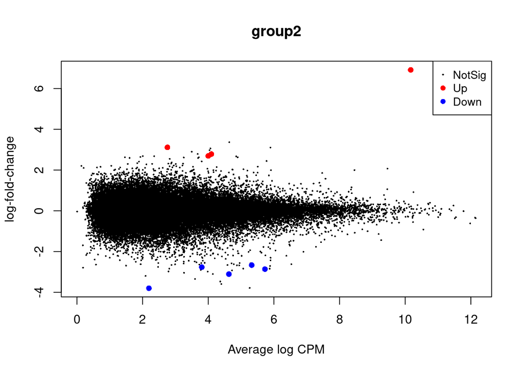

```r
plotMD(lrt)
```

The summary chart for likelihood ratio tests method confirmed the previously performed statistical analyses.

### DESeq2

The package DESeq2 provides methods to test for differential expression by use of negative binomial generalized linear models; the estimates of dispersion and logarithmic fold changes incorporate data-driven prior distributions.

In this example, the “DESeqDataSetFromMatrix” function creates a DESeqDataSet object from the count data and design matrix. The “DESeq” function performs the differential expression analysis, and the results are obtained using the “results” function. Finally, the differentially expressed genes are identified based on an adjusted p-value threshold of 0.05.

#### DESeq2 for genes

**Step 1:** Preparing data

```r
library(DESeq2)

#create a matrix with sample info (with sample names in rows)
colData <- data.frame(colnames(genes.merged), condition = factor(c(1, 1, 0, 0)))
rownames(colData) <- colnames(genes.merged)
```

```r
#making sure the row names in colData matches to column names in countData (genes.merged)
all(colnames(genes.merged) %in% rownames(colData))
```

```
## [1] TRUE
```

```r
#checking are they in the same order
all(colnames(genes.merged) == rownames(colData))
```

```
## [1] TRUE
```

**Step 2:** Construct a DESeqDataSet object

```r
#create a DESeqDataSet
#the "round" function is used because the variable countData takes a matrix of non-negative integers
#the "design" variable groups samples into overexpressed (1) and wild type (0)

dds <- DESeqDataSetFromMatrix(countData=round(genes.merged), colData=colData,
                             design = ~ condition)
```

The next step may be to filter the data through removing rows with low gene counts. It is recommended to keep rows that have at least 10 reads total. This step is recommended but not required, therefore this step is omitted from this analysis (in particular to compare the results with previous analyzes that did not include this step).

```r
#set the factor level - to determine the reference group
dds$condition <- relevel(dds$condition, ref = "0")
```

**Step 3:** Run DESeq analysis

```r
#run the DESeq
dds <- DESeq(dds)
#get the results
res <- results(dds)
res
```

```
## log2 fold change (MLE): condition 1 vs 0
## Wald test p-value: condition 1 vs 0
## DataFrame with 23905 rows and 6 columns
##            baseMean log2FoldChange     lfcSE       stat    pvalue      padj
##           <numeric>      <numeric> <numeric>  <numeric> <numeric> <numeric>
## AT1G01010  103.7681     -0.5453410  0.469136  -1.162437  0.245058  0.999979
## AT1G01020  100.1534     -0.1803865  0.467755  -0.385643  0.699761  0.999979
## AT1G01030   50.3712      0.3669331  0.559659   0.655637  0.512058  0.999979
## AT1G01040  381.3428      0.0698157  0.425769   0.163976  0.869750  0.999979
## AT1G01050  215.1068     -0.3544146  0.484815  -0.731031  0.464760  0.999979
## ...             ...            ...       ...        ...       ...       ...
## AT5G67600 102.21314     -0.4847860  0.541079 -0.8959610  0.370274  0.999979
## AT5G67610 109.93159     -0.3139327  0.468283 -0.6703912  0.502608  0.999979
## AT5G67620   7.46288      0.0214516  1.064142  0.0201586  0.983917  0.999979
## AT5G67630 280.59973     -0.0596366  0.413997 -0.1440507  0.885460  0.999979
## AT5G67640  52.10614     -0.1124611  0.561072 -0.2004395  0.841137  0.999979
```

Log-fold change parameter is calculating for “condition” factor between over expressed (1) and wild type (0). All of values for logFC are only for over expressed because they are compared to the wild type. Positive values of the logFC parameter determine the up regulation. On the other hand, negative values of the logFC parameter determine the down regulation.The statistical test used is the Wald test. The resulting dataframe has multiple columns: baseMean (same as Average expression), log2FoldChange (fold-change for gene in over expressed condition with compared to the wild type), lfcSE (standard error estimates for logFC), stat (Wald test values for these genes), pvalue (p-value of the test statistic for this genes), padj (corrected p-values for multiple testing).

Overall, we can conclude that we have obtained similar statistics and information from previous analyses, but with different assays (variable names).

**Step 4:** Explore results

```r
summary(res)
```

```
##
## out of 23905 with nonzero total read count
## adjusted p-value < 0.1
## LFC > 0 (up)       : 1, 0.0042%
## LFC < 0 (down)     : 4, 0.017%
## outliers [1]       : 0, 0%
## low counts [2]     : 0, 0%
## (mean count < 1)
## [1] see 'cooksCutoff' argument of ?results
## [2] see 'independentFiltering' argument of ?results
```

The summary shows how many down-regulated genes and how many up-regulated genes are present, as well as the number of low-count reads or outliers. Currently it is using an adjusted p-value threshold of less than 0.1, but we can change this.

```r
new.res <- results(dds, alpha = 0.05)
summary(new.res)
```

```
##
## out of 23905 with nonzero total read count
## adjusted p-value < 0.05
## LFC > 0 (up)       : 1, 0.0042%
## LFC < 0 (down)     : 3, 0.013%
## outliers [1]       : 0, 0%
## low counts [2]     : 0, 0%
## (mean count < 1)
## [1] see 'cooksCutoff' argument of ?results
## [2] see 'independentFiltering' argument of ?results
```

We can see that after p-adjusted the results have changed, but only slightly.

```r
#find the differentially expressed genes
res.dif <- res[which(res$padj < 0.05), ]
res.dif
```

```
## log2 fold change (MLE): condition 1 vs 0
## Wald test p-value: condition 1 vs 0
## DataFrame with 4 rows and 6 columns
##            baseMean log2FoldChange     lfcSE      stat      pvalue        padj
##           <numeric>      <numeric> <numeric> <numeric>   <numeric>   <numeric>
## AT1G43800  156.7394       -3.46874  0.634994  -5.46263 4.69135e-08 5.60734e-04
## AT3G01150 8962.5890        6.12153  0.403376  15.17577 5.11762e-52 1.22337e-47
## AT3G12500  205.8780       -2.19566  0.451543  -4.86257 1.15872e-06 9.23303e-03
## AT5G35935   41.3868       -3.12397  0.666234  -4.68900 2.74540e-06 1.64072e-02
```

```r
sum(res.dif$padj < 0.05)
```

```
## [1] 4
```

**Step 5:** Visual examination - MA plot

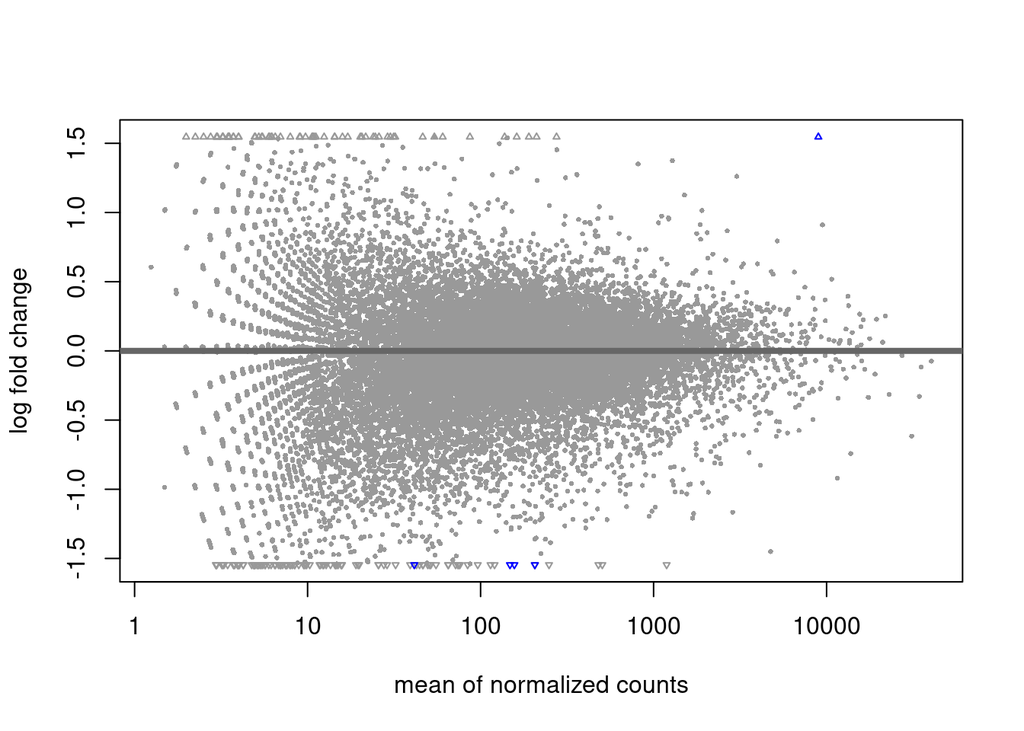

```r
plotMA(res)
```

Below are two more ways to visualize data using the plot() and ggplot() functions.

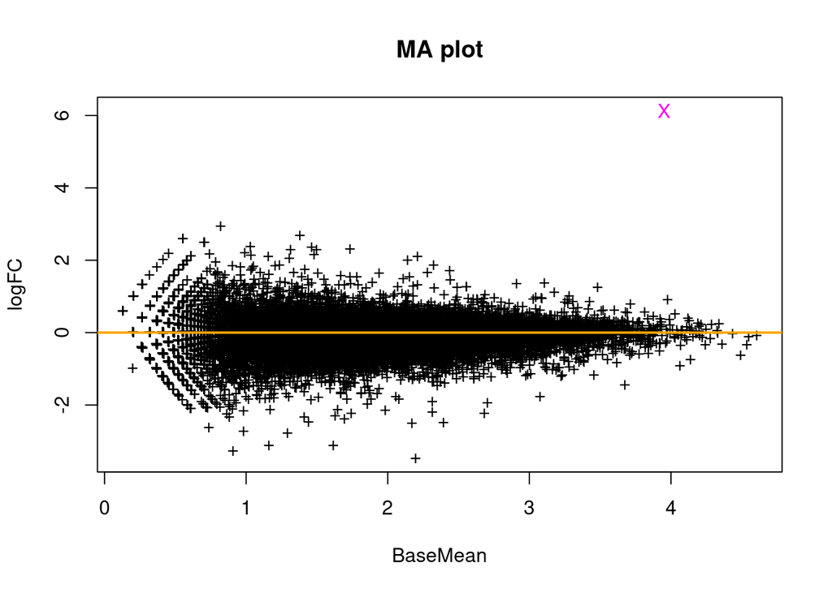

```r
gen.sel <- "AT3G01150"

pchs <- rep("+", dim(res)[1])
cols <- rep("black", dim(res)[1])
names(pchs) <- names(cols) <- rownames(res)

pchs[gen.sel] <- "X"
cols[gen.sel] <- "magenta"

plot(log10(res$baseMean+0.1), res$log2FoldChange,
     xlab = "BaseMean", ylab="logFC", main = "MA plot", pch=pchs, col=cols)
abline(h=0, col="orange", lwd=2)

points(res[gen.sel,]$baseMean,
       res[gen.sel,]$log2FoldChange,
       pch=pchs[gen.sel], col=cols[gen.sel])
```

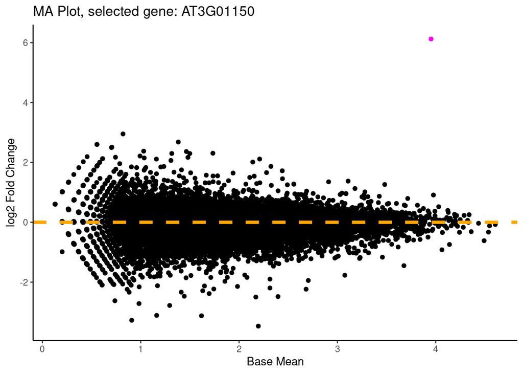

```r
library(ggplot2)

#get the gene with the highest expression
gen.sel <- "AT3G01150"

#create a data frame for plotting
df <- data.frame(gene=rownames(res), baseMean=log10(res$baseMean+0.1), log2FoldChange=res$log2FoldChange)

#create a new column indicating the selected gene
df$selected <- ifelse(df$gene == gen.sel, 1, 0)

#plot the MA plot with the selected gene marked
ggplot(df, aes(x=baseMean, y=log2FoldChange, color=as.factor(selected))) +
  geom_point() +
  geom_hline(yintercept=0, color="orange", linetype="dashed", size=1.5) +
  scale_color_manual(values=c("black", "magenta"), guide=FALSE) +
  xlab("Base Mean") +
  ylab("log2 Fold Change") +
  ggtitle(paste0("MA Plot, selected gene: ", gen.sel)) +
  theme_classic()
```

Both plots look very similar and confirm a high expression with a statistically significant score for our gene of interest.

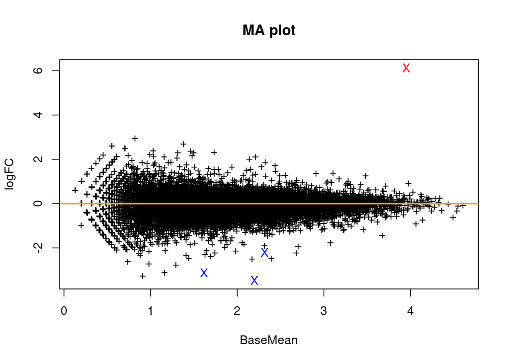

```r
gen.sel <- "AT3G01150"

pchs <- rep("+", dim(res)[1])
cols <- rep("black", dim(res)[1])
names(pchs) <- names(cols) <- rownames(res)

res <- res[complete.cases(res$padj), ] #it is necessary to remove the 'NA' values
sig <- res$padj < 0.05
sel_row <- rownames(res) == gen.sel


#determining the shape of the points to distinguish the significant from the non-significant
pchs[sig] <- "X"
pchs[!sig] <- "+"

#specifying the color of points to distinguish significant from non-significant, as well as to distinguish gen.sel
cols[sig & !sel_row] <- "blue"
cols[sel_row] <- "red"

plot(log10(res$baseMean+0.1), res$log2FoldChange,
     xlab = "BaseMean", ylab="logFC", main = "MA plot", pch=pchs, col=cols)
abline(h=0, col="orange", lwd=2)
```

#### DESeq2 for transcripts

**Step 1:** Preparing data

```r
library(DESeq2)

#create a matrix with sample info (with sample names in rows)
colData <- data.frame(colnames(trans.merged), condition = factor(c(1, 1, 0, 0)))
rownames(colData) <- colnames(trans.merged)
```

```r
#making sure the row names in colData matches to column names in countData (trans.merged)
all(colnames(trans.merged) %in% rownames(colData))
```

```
## [1] TRUE
```

```r
#checking are they in the same order
all(colnames(trans.merged) == rownames(colData))
```

```
## [1] TRUE
```

**Step 2:** Construct a DESeqDataSet object

```r
#create a DESeqDataSet
dds <- DESeqDataSetFromMatrix(countData=round(trans.merged), colData=colData,
                             design = ~ condition)
#set the factor level - to determine the reference group
dds$condition <- relevel(dds$condition, ref = "0")
```

**Step 3:** Run DESeq analysis

```r
#run the DESeq
dds <- DESeq(dds)
#get the results
res <- results(dds)
res
```

```
## log2 fold change (MLE): condition 1 vs 0
## Wald test p-value: condition 1 vs 0
## DataFrame with 57408 rows and 6 columns
##                baseMean log2FoldChange     lfcSE       stat    pvalue      padj
##               <numeric>      <numeric> <numeric>  <numeric> <numeric> <numeric>
## AT1G01010_ID1  104.0780     -0.5494058  0.575357 -0.9548951  0.339631  0.999985
## AT1G01020_ID8   17.1520     -0.6238776  0.781829 -0.7979717  0.424887        NA
## AT1G01020_ID9   28.6455      0.0865252  0.704355  0.1228430  0.902231        NA
## AT1G01020_ID4   11.7146      0.0714514  0.863546  0.0827419  0.934057        NA
## AT1G01020_ID5   12.7152      0.0659328  0.847376  0.0778082  0.937981        NA
## ...                 ...            ...       ...        ...       ...       ...
## AT5G67630_ID2  155.4281       0.196448  0.566140   0.346996  0.728594  0.999985
## AT5G67630_ID1  125.6509      -0.372873  0.566572  -0.658121  0.510461  0.999985
## AT5G67640_ID2   24.8427      -0.214883  0.734050  -0.292735  0.769724        NA
## AT5G67640_ID3   16.4815       0.536443  0.857826   0.625352  0.531740        NA
## AT5G67640_ID4   10.7213      -0.893107  0.932224  -0.958038  0.338043        NA
```

The table contains the same components as in the previous section, but refers to the transcripts.

**Step 4:** Explore results

```r
new.res <- results(dds, alpha = 0.05)
summary(new.res)
```

```
##
## out of 57408 with nonzero total read count
## adjusted p-value < 0.05
## LFC > 0 (up)       : 5, 0.0087%
## LFC < 0 (down)     : 9, 0.016%
## outliers [1]       : 0, 0%
## low counts [2]     : 23372, 41%
## (mean count < 19)
## [1] see 'cooksCutoff' argument of ?results
## [2] see 'independentFiltering' argument of ?results
```

```r
#find the differentially expressed transcripts
res.dif <- res[which(res$padj < 0.05), ]
res.dif
```

```
## log2 fold change (MLE): condition 1 vs 0
## Wald test p-value: condition 1 vs 0
## DataFrame with 13 rows and 6 columns
##                  baseMean log2FoldChange     lfcSE      stat      pvalue
##                 <numeric>      <numeric> <numeric> <numeric>   <numeric>
## AT1G43800_ID1     158.616       -3.48571  0.737661  -4.72536 2.29709e-06
## AT2G36530_ID120   129.872        2.79377  0.601062   4.64806 3.35074e-06
## AT3G01150_ID4    8822.403        6.91217  0.541521  12.76437 2.59256e-37
## AT3G10970_ID10    105.736       -2.77244  0.601367  -4.61024 4.02212e-06
## AT3G51370_ID7     228.525        2.63070  0.617524   4.26008 2.04350e-05
## ...                   ...            ...       ...       ...         ...
## AT4G14880_ID19   406.8757       -2.86862  0.578275  -4.96065 7.02575e-07
## AT4G19410_ID16   158.6573       -3.57903  0.772609  -4.63239 3.61462e-06
## AT4G24440_ID7     49.9693        3.10175  0.699411   4.43480 9.21591e-06
## AT5G46210_ID7    103.3966       -2.92920  0.672095  -4.35831 1.31068e-05
## AT5G52650_ID2    298.2497       -2.56947  0.596889  -4.30477 1.67160e-05
##                        padj
##                   <numeric>
## AT1G43800_ID1   1.09563e-02
## AT2G36530_ID120 1.09563e-02
## AT3G01150_ID4   5.64970e-33
## AT3G10970_ID10  1.09563e-02
## AT3G51370_ID7   3.42553e-02
## ...                     ...
## AT4G14880_ID19   0.00765526
## AT4G19410_ID16   0.01095626
## AT4G24440_ID7    0.02008331
## AT5G46210_ID7    0.02596584
## AT5G52650_ID2    0.03035617
```

```r
sum(res.dif$padj < 0.05)
```

```
## [1] 13
```

```r
genes <- rownames(res.dif)
log2FoldChange <- res.dif$log2FoldChange
padj <- res.dif$padj

results_df <- data.frame(gene = genes, log2FoldChange = log2FoldChange, padj = padj)
results_df
```

```
##               gene log2FoldChange         padj
## 1    AT1G43800_ID1      -3.485714 1.095626e-02
## 2  AT2G36530_ID120       2.793773 1.095626e-02
## 3    AT3G01150_ID4       6.912167 5.649696e-33
## 4   AT3G10970_ID10      -2.772443 1.095626e-02
## 5    AT3G51370_ID7       2.630703 3.425531e-02
## 6    AT3G52220_ID3       2.707567 1.102595e-02
## 7    AT4G01800_ID1      -2.680727 1.095626e-02
## 8   AT4G14880_ID12      -3.091630 1.095626e-02
## 9   AT4G14880_ID19      -2.868619 7.655262e-03
## 10  AT4G19410_ID16      -3.579030 1.095626e-02
## 11   AT4G24440_ID7       3.101747 2.008331e-02
## 12   AT5G46210_ID7      -2.929201 2.596584e-02
## 13   AT5G52650_ID2      -2.569470 3.035617e-02
```

As a result, we receive information about 13 transcripts that show a statistically significant expression (padj < 0.05), of which the only transcript significantly differs from the others in terms of the high log-fold change parameter and again it is AT3G01150_ID4.

**Step 5:** Visual examination - MA plot

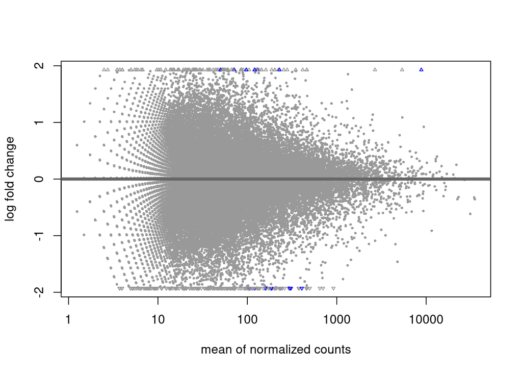

```r
plotMA(res)
```

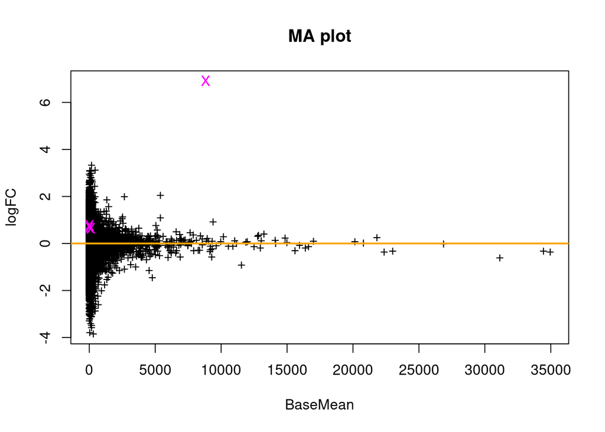

```r
gen.sel <- "AT3G01150"
trans.sel <- mapping[mapping[,"genes"] == gen.sel, "transcripts"]

pchs <- rep("+", dim(res)[1])
cols <- rep("black", dim(res)[1])
names(pchs) <- names(cols) <- rownames(res)

pchs[trans.sel] <- "X"
cols[trans.sel] <- "magenta"

plot(res$baseMean, res$log2FoldChange,
     xlab = "BaseMean", ylab="logFC", main = "MA plot", pch=pchs, col=cols)
abline(h=0, col="orange", lwd=2)

points(res[trans.sel,]$baseMean,
       res[trans.sel,]$log2FoldChange,
       pch=pchs[trans.sel], col=cols[trans.sel])
```

The graph shows all transcripts for the gene - AT3G01150. Only one of them differs significantly from the others and shows a high level of expression.

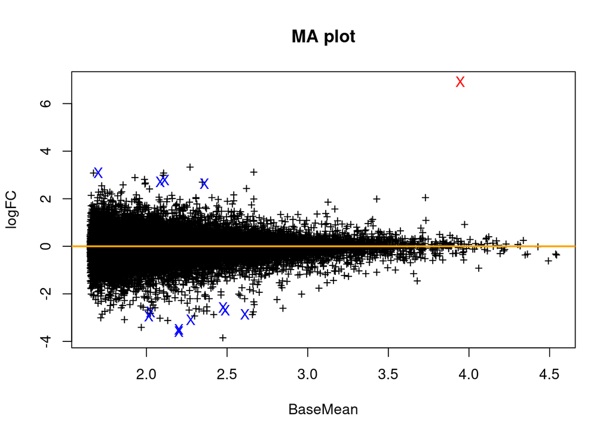

```r
gen.sel <- "AT3G01150"
trans.sel <- mapping[mapping[,"genes"] == gen.sel, "transcripts"]

pchs <- rep("+", dim(res)[1])
cols <- rep("black", dim(res)[1])
names(pchs) <- names(cols) <- rownames(res)

res <- res[complete.cases(res$padj), ] #it is necessary to remove the 'NA' values
sig <- res$padj < 0.05
sel_row <- rownames(res) == trans.sel


#determining the shape of the points to distinguish the significant from the non-significant
pchs[sig] <- "X"
pchs[!sig] <- "+"

#specifying the color of points to distinguish significant from non-significant, as well as to distinguish gen.sel
cols[sig & !sel_row] <- "blue"
cols[sel_row] <- "red"

plot(log10(res$baseMean+0.1), res$log2FoldChange,
     xlab = "BaseMean", ylab="logFC", main = "MA plot", pch=pchs, col=cols)
abline(h=0, col="orange", lwd=2)
```

The chart includes all transcripts showing statistically significant results (padj-value less than 0.05). The graph takes into account the logarithmic transformation for the baseMean, due to the wide range of values of this variable. The distribution of the data changed slightly (less noise) after removing the rows with NA values (especially those rows with NA values for padj). But in general, the most important information about the unique over expression of one of the transcripts has been captured. Therefore, we can say that the cumulative chart confirms the performed statistical analysis.

# Summary

To summarize, the analysis provided information about the unique up regulation of the gene **AT3G01150** and the corresponding **ID4** transcript. Each of the methods used to study differential expression showed distinct characteristics and results, but all of them singled out this particular gene and transcript as the most important in the analysis. Each of the tests was characterized by a different accuracy and severity in evaluating the data. The differences in the results of differential expression methods such as limma, edgeR, and DESeq can come from various sources:

- **Statistical model:** The statistical models used by each method to calculate the significance of differential gene/transcript expression are different, leading to different results.
- **Data normalization:** Different normalization methods can affect the results, particularly when the data has high levels of variability or technical noise.
- **Batch effects correction:** The methods used to correct for batch effects, a systematic bias that can occur when samples are processed in different batches, can also affect the results.
- **Outlier handling:** The methods used to handle outliers, which can be caused by technical issues or biological variability, can also influence the results.
- **Fold change calculation:** The methods used to calculate fold changes, which are used to quantify the magnitude of differential gene/transcript expression, can also vary between methods and impact the results.

In conclusion, the choice of differential gene/transcript expression method should be based on the specifics of the experiment, the quality of the data, and the biological question being asked.